# P.pajaritus_CMH-I

Andrea Arriaga-Madrigal, Paula Iturralde y Silvia Chaves

2020-11-17

## Modelo 1. Silvia

Se estudió el efecto que tienen diferentes indicadores H de degradación ambiental sobre diversidad alélica (D) del complejo CMH-I de *P. pajaritus*

Para esto apliqué modelos lineales para ver el efectos de cada indeicador H sobre D

```r
# Para H1
h1 <- glm(D ~ H1 + A + P + L, data= datos, family = "poisson")
h1
```

```
##
## Call:  glm(formula = D ~ H1 + A + P + L, family = "poisson", data = datos)
##
## Coefficients:
## (Intercept)           H1            A            P            L
##     3.80621     -0.05242     -0.26895      0.04793     -0.06196
##
## Degrees of Freedom: 599 Total (i.e. Null);  595 Residual
## Null Deviance:       1613
## Residual Deviance: 1151  AIC: 4511
```

```r
S.H1 <- summary(h1)
S.H1
```

```
##
## Call:
## glm(formula = D ~ H1 + A + P + L, family = "poisson", data = datos)
##
## Deviance Residuals:
##     Min       1Q   Median       3Q      Max
## -4.7208  -0.6056   0.1591   0.8909   2.4660
##
## Coefficients:
##              Estimate Std. Error z value Pr(>|z|)
## (Intercept)  3.806206   0.016202 234.928  < 2e-16 ***
## H1          -0.052425   0.006651  -7.882 3.22e-15 ***
## A           -0.268946   0.022215 -12.106  < 2e-16 ***
## P            0.047928   0.003671  13.055  < 2e-16 ***
## L           -0.061959   0.007497  -8.265  < 2e-16 ***
## ---
## Signif. codes:  0 '***' 0.001 '**' 0.01 '*' 0.05 '.' 0.1 ' ' 1
##
## (Dispersion parameter for poisson family taken to be 1)
##
##     Null deviance: 1612.8  on 599  degrees of freedom
## Residual deviance: 1151.4  on 595  degrees of freedom
## AIC: 4510.6
##
## Number of Fisher Scoring iterations: 4
```

```r
# Para H2
h2 <- glm(D ~ H2+ A + P + L, data=datos,family = "poisson")

h2
```

```
##
## Call:  glm(formula = D ~ H2 + A + P + L, family = "poisson", data = datos)
##
## Coefficients:
## (Intercept)           H2            A            P            L
##     3.80914     -0.01894     -0.25525      0.04556     -0.08563
##
## Degrees of Freedom: 599 Total (i.e. Null);  595 Residual
## Null Deviance:       1613
## Residual Deviance: 1207  AIC: 4566
```

```r
S.H2 <- summary(h2)
S.H2
```

```
##
## Call:
## glm(formula = D ~ H2 + A + P + L, family = "poisson", data = datos)
##
## Deviance Residuals:
##     Min       1Q   Median       3Q      Max
## -5.3063  -0.4699   0.2048   0.8513   2.4913
##
## Coefficients:
##              Estimate Std. Error z value Pr(>|z|)
## (Intercept)  3.809135   0.016228 234.728   <2e-16 ***
## H2          -0.018936   0.007355  -2.575     0.01 *
## A           -0.255254   0.022647 -11.271   <2e-16 ***
## P            0.045564   0.003750  12.151   <2e-16 ***
## L           -0.085633   0.007267 -11.783   <2e-16 ***
## ---
## Signif. codes:  0 '***' 0.001 '**' 0.01 '*' 0.05 '.' 0.1 ' ' 1
##
## (Dispersion parameter for poisson family taken to be 1)
##
##     Null deviance: 1612.8  on 599  degrees of freedom
## Residual deviance: 1206.9  on 595  degrees of freedom
## AIC: 4566.1
##
## Number of Fisher Scoring iterations: 4
```

```r
# Para H3
h3 <- glm(D ~ H3+ A + P + L, data=datos,family = "poisson")
h3
```

```
##
## Call:  glm(formula = D ~ H3 + A + P + L, family = "poisson", data = datos)
##
## Coefficients:
## (Intercept)           H3            A            P            L
##     3.82150     -0.01463     -0.27165      0.04818     -0.07738
##
## Degrees of Freedom: 599 Total (i.e. Null);  595 Residual
## Null Deviance:       1613
## Residual Deviance: 1209  AIC: 4569
```

```r
S.H3 <- summary(h3)
S.H3
```

```
##
## Call:
## glm(formula = D ~ H3 + A + P + L, family = "poisson", data = datos)
##
## Deviance Residuals:
##     Min       1Q   Median       3Q      Max
## -5.3274  -0.5753   0.2408   0.8494   2.5078
##
## Coefficients:
##              Estimate Std. Error z value Pr(>|z|)
## (Intercept)  3.821502   0.016809 227.355   <2e-16 ***
## H3          -0.014630   0.007196  -2.033    0.042 *
## A           -0.271651   0.022423 -12.115   <2e-16 ***
## P            0.048180   0.003697  13.030   <2e-16 ***
## L           -0.077380   0.007374 -10.494   <2e-16 ***
## ---
## Signif. codes:  0 '***' 0.001 '**' 0.01 '*' 0.05 '.' 0.1 ' ' 1
##
## (Dispersion parameter for poisson family taken to be 1)
##
##     Null deviance: 1612.8  on 599  degrees of freedom
## Residual deviance: 1209.4  on 595  degrees of freedom
## AIC: 4568.6
##
## Number of Fisher Scoring iterations: 4
```

```r
# Para H4
h4 <- glm(D ~ H4+ A + P + L, data=datos, family = "poisson")
h4
```

```
##
## Call:  glm(formula = D ~ H4 + A + P + L, family = "poisson", data = datos)
##
## Coefficients:
## (Intercept)           H4            A            P            L
##     3.85709     -0.12289     -0.18564      0.03163     -0.01819
##
## Degrees of Freedom: 599 Total (i.e. Null);  595 Residual
## Null Deviance:       1613
## Residual Deviance: 951   AIC: 4310
```

```r
S.H4 <- summary(h4)
S.H4
```

```
##
## Call:
## glm(formula = D ~ H4 + A + P + L, family = "poisson", data = datos)
##
## Deviance Residuals:
##     Min       1Q   Median       3Q      Max
## -4.5937  -0.5918   0.2213   0.7883   2.3590
##
## Coefficients:
##              Estimate Std. Error z value Pr(>|z|)
## (Intercept)  3.857089   0.016251 237.345  < 2e-16 ***
## H4          -0.122890   0.007545 -16.288  < 2e-16 ***
## A           -0.185644   0.022998  -8.072  6.9e-16 ***
## P            0.031628   0.003845   8.225  < 2e-16 ***
## L           -0.018188   0.008054  -2.258   0.0239 *
## ---
## Signif. codes:  0 '***' 0.001 '**' 0.01 '*' 0.05 '.' 0.1 ' ' 1
##
## (Dispersion parameter for poisson family taken to be 1)
##
##     Null deviance: 1612.75  on 599  degrees of freedom
## Residual deviance:  951.03  on 595  degrees of freedom
## AIC: 4310.2
##
## Number of Fisher Scoring iterations: 4
```

```r
#Para H5
h5 <- glm(D ~ H5+ A + P + L, data=datos, family = "poisson")
h5
```

```
##
## Call:  glm(formula = D ~ H5 + A + P + L, family = "poisson", data = datos)
##
## Coefficients:
## (Intercept)           H5            A            P            L
##     3.81021      0.01389     -0.26059      0.04656     -0.09091
##
## Degrees of Freedom: 599 Total (i.e. Null);  595 Residual
## Null Deviance:       1613
## Residual Deviance: 1210  AIC: 4569
```

```r
S.H5 <- summary(h5)
S.H5
```

```
##
## Call:
## glm(formula = D ~ H5 + A + P + L, family = "poisson", data = datos)
##
## Deviance Residuals:
##     Min       1Q   Median       3Q      Max
## -5.4144  -0.5890   0.2047   0.8562   2.4828
##
## Coefficients:
##              Estimate Std. Error z value Pr(>|z|)
## (Intercept)  3.810212   0.016226 234.819   <2e-16 ***
## H5           0.013888   0.007071   1.964   0.0495 *
## A           -0.260591   0.022422 -11.622   <2e-16 ***
## P            0.046564   0.003705  12.568   <2e-16 ***
## L           -0.090913   0.008569 -10.610   <2e-16 ***
## ---
## Signif. codes:  0 '***' 0.001 '**' 0.01 '*' 0.05 '.' 0.1 ' ' 1
##
## (Dispersion parameter for poisson family taken to be 1)
##
##     Null deviance: 1612.8  on 599  degrees of freedom
## Residual deviance: 1209.7  on 595  degrees of freedom
## AIC: 4568.9
##
## Number of Fisher Scoring iterations: 4
```

Ahora comparamos los efectos de los indicadores de degradación

```r
# Se estraen  valor de P  para cada modelo
P.H1 <- S.H1$coefficients[2,4]
P.H2 <- S.H2$coefficients[2,4]
P.H3 <- S.H3$coefficients[2,4]
P.H4 <- S.H4$coefficients[2,4]
P.H5 <- S.H5$coefficients[2,4]
```

Creamos un marco de datos con los valores de p para cada indicador de desgradación ambiental evaluado.

```r
R <- data.frame("Indicador"= c("H1","H2", "H3", "H4", "H5"), "Valores de P"=c(P.H1, P.H2, P.H3, P.H4, P.H5))
R
```

| Indicador | Valores.de.P |
| --- | --- |
| H1 | 3.220530e-15 |
| H2 | 1.003395e-02 |
| H3 | 4.204383e-02 |
| H4 | 1.208294e-59 |
| H5 | 4.951158e-02 |

Visualizamos los datos

```r
grid.arrange(p1, p2, p3, p4, p5)
```

[figure not shown]

**Fig 1.** Variación de la diversidad alélica del complejo mayor de histocompatibilidad (CMH) clase I, según los indicadores de degradación presentes en el sitio. Las líneas azules representa la tendencia general de los datos para cada indicador y área sombreada en gris el intervalo de confianza al 95%

### Correción modelo 3. Andrea

Si se van a incluir las variables predictoras (H1, H2, H3, H4 y H5) juntas en el modelo, una buena forma de reducción de dimensiones es realizar un análisis de componentes principales. De esta forma se puede calcular el eje de mayor variación atribuido a las variables predictoras en conjunto y asignar un valor a cada observación respecto a su distancia a dicho eje. Esta nueva variable resume la variación dada por todas las H en conjunto y va a ser llamada **“degradación”** (fig. 1).

```r
# PCA
Hpca <- princomp(datos[,c("H1", "H2", "H3", "H4", "H5")])

summary(Hpca)
```

```
## Importance of components:
##                           Comp.1    Comp.2    Comp.3    Comp.4    Comp.5
## Standard deviation     1.2525935 0.9530683 0.9286312 0.8464311 0.8215138
## Proportion of Variance 0.3316392 0.1919966 0.1822771 0.1514359 0.1426511
## Cumulative Proportion  0.3316392 0.5236358 0.7059130 0.8573489 1.0000000
```

```r
## extrayendo los scrores del primer componente principal para hacerlo una nueva variable que agrupa todas las H
datos$degradacion <- Hpca$scores[,1]
```

Cuadro 1. Visualización de las primeras seis filas de la base de datos, ahora con la nueva variable “degradación”.

|  | A | P | L | H1 | H2 | H3 | H4 | H5 | D | degradacion |
| --- | --- | --- | --- | --- | --- | --- | --- | --- | --- | --- |
| 1 | 1 | 1 | 0.03 | 0.32 | -1.01 | 0.34 | 2.35 | -1.05 | 22 | 0.814897 |
| 2 | 1 | 1 | 0.03 | 0.32 | -1.01 | 0.34 | 2.35 | -1.05 | 21 | 0.814897 |
| 3 | 1 | 1 | 0.03 | 0.32 | -1.01 | 0.34 | 2.35 | -1.05 | 23 | 0.814897 |
| 4 | 1 | 1 | 0.03 | 0.32 | -1.01 | 0.34 | 2.35 | -1.05 | 21 | 0.814897 |
| 5 | 1 | 1 | 0.03 | 0.32 | -1.01 | 0.34 | 2.35 | -1.05 | 22 | 0.814897 |
| 6 | 1 | 1 | 0.03 | 0.32 | -1.01 | 0.34 | 2.35 | -1.05 | 22 | 0.814897 |

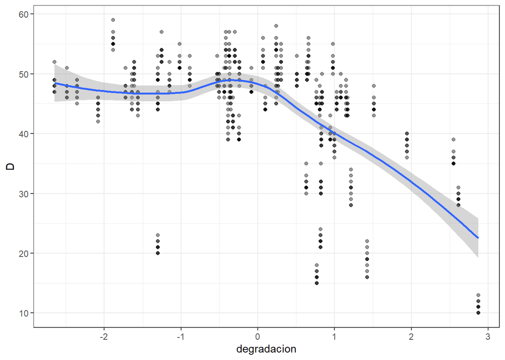

El modelo 3 está incorrecto, ya que presenta la trampa estadística de **inflación de N**, al asumir que todos los datos son parte de la misma muestra. El modelo correcto se lleva a cabo usando la variable **degradación** y la latitud (**L**) como variables predictoras de efectos fijos. Sin embargo, para que el modelo permita observar la variación atribuida a la degradación sin que se vea enmascarada por la variación dada por la población a la que pertenece cada indiviuo (fig. 2) o al año en que fueron tomados estos datos, es necesario incluir ambas (i.e. **P** y **A**) como variables de efectos aleatorios.

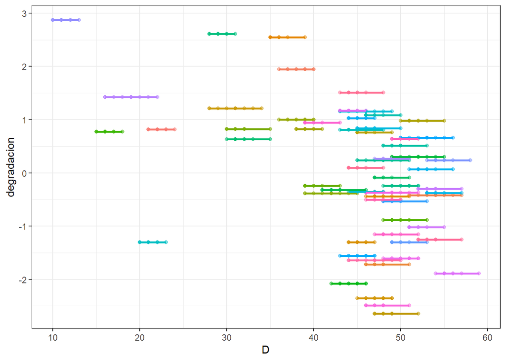

Fig 2. Variación de la diversidad alélica (**D**) según la degradación del sitio (**degradacion**). Cada color representa una población diferente.

Para esto el modelo se plantea de la siguiente manera:

## Modelo 4. Andrea Arriaga

```r
## Modelo correcto: incluye la poblacion y el año como efecto aleatorio
 mod1 <- glmer(D ~ degradacion + (1|P) + (1|A) + L, data = datos, family = "poisson")
 summ(mod1)
```

```
## MODEL INFO:
## Observations: 600
## Dependent Variable: D
## Type: Mixed effects generalized linear regression
## Error Distribution: poisson
## Link function: log
##
## MODEL FIT:
## AIC = 3653.53, BIC = 3675.52
## Pseudo-R² (fixed effects) = 0.17
## Pseudo-R² (total) = 0.79
##
## FIXED EFFECTS:
## ------------------------------------------------
##                      Est.   S.E.   z val.      p
## ----------------- ------- ------ -------- ------
## (Intercept)          3.74   0.04    98.61   0.00
## degradacion         -0.11   0.04    -2.89   0.00
## L                   -0.00   0.05    -0.09   0.92
## ------------------------------------------------
##
## RANDOM EFFECTS:
## ---------------------------------
##  Group    Parameter    Std. Dev.
## ------- ------------- -----------
##    P     (Intercept)     0.26
##    A     (Intercept)     0.00
## ---------------------------------
##
## Grouping variables:
## -------------------------
##  Group   # groups   ICC
## ------- ---------- ------
##    P        60      0.06
##    A        10      0.00
## -------------------------
```

**Interpretación:** Los resultados indican que todos los parámetros de degradación ambiental evaluados (H1, H2, H3, H4, H5), tienen un efecto significativo sobre la diversidad alélica (z = -2.89, p < 0.01) del complejo mayor de histocompatibilidad (CMH) clase I.

### Corrección Modelo 4. Silvia

Según lo planteado para el uso del Modelo 4, este modelo es correcto si lo que deseamos es obtener el efecto que tienen todos los indicadores ambientales en conjunto sobre D. Sin embargo, la interpretación sobre su resultado es incorrecta y representa una trampa estadística de reporte selectivo. Debido a que se está reportando y asumiendo que el efecto que tiene cada uno de los indicadores ambientales (H1, H2, H3, H4, H5) sobre D es el mismo, cuando lo que se quiere averiguar es el efecto del mayor eje de variación **degradación** (determinado con un análisis de **PCA**) sobre nuestra variable D. Por lo tanto se debería concluir que, de forma general, la diversidad alélica del complejo mayor de histocompatibilidad (CMH) clase I si es afectada por la degradación ambiental.